# Term1_MachineLearning_CA1_sba23167_xiu-shi

```python
from sklearn.linear_model import LogisticRegression
from sklearn.model_selection import cross_val_score
from sklearn.svm import SVC
from scipy.stats import ttest_rel
import numpy as np

# 🕒 Start timer
start_time = time.time()

## Refit the preprocessor on X_train
X_processed = preprocessor.fit_transform(X_train)
y_array = y_train.to_numpy()

## Ensure alignment between features and labels
## "Mismatch between X and y"
assert X_processed.shape[0] == len(y_array)

## Reduce dataset size to speed up training and cross-validation
## Justification:
## The full dataset is large (~115k rows), causing long runtimes
## For model comparison (not final training), a smaller random sample (e.g., 5,000) provides a statistically reliable estimate

sample_size = min(5000, X_processed.shape[0])
sample_indices = np.random.choice(X_processed.shape[0], sample_size, replace=False)

## subset X and y
X_sample = X_processed[sample_indices]
y_sample = y_array[sample_indices]

## Define models for comparison
## Logistic Regression
lr = LogisticRegression(max_iter=5000, random_state=42)
## Support Vector Machine
svm = SVC(kernel="linear", probability=False, max_iter=5000, random_state=42)

## Cross-validation on the smaller sample
cv_scores_lr = cross_val_score(lr, X_sample, y_sample, cv=3, scoring="accuracy")
cv_scores_svm = cross_val_score(svm, X_sample, y_sample, cv=3, scoring="accuracy")

## Output results
print("Logistic Regression CV Accuracy:", np.round(cv_scores_lr, 4))
print("SVM (Linear) CV Accuracy:", np.round(cv_scores_svm, 4))

## Paired t-test: Statistical comparison of model performance
stat, p_value = ttest_rel(cv_scores_lr, cv_scores_svm)
print(f"\nPaired t-test: statistic={stat:.4f}, p-value={p_value:.4f}")
if p_value < 0.05:
    print("Statistically significant difference between models")
else:
    print("No statistically significant difference between models")


end_time = time.time()
elapsed_time = end_time - start_time
print(f"\n⏱️ Classification approach block took {elapsed_time:.2f} seconds to run.")
```

```
Logistic Regression CV Accuracy: [0.8548 0.8542 0.8559]
SVM (Linear) CV Accuracy: [0.8548 0.8548 0.8553]

Paired t-test: statistic=0.0003, p-value=0.9998
No statistically significant difference between models

⏱️ Classification approach block took 0.60 seconds to run.
```

```
🔎 Support Vector Machine (SVM) Classification Report:
                       precision    recall  f1-score   support

       Loyal (Slight)       0.90      0.66      0.76     24819
Churn (Serious/Fatal)       0.21      0.55      0.30      4065

             accuracy                           0.64     28884
            macro avg       0.56      0.61      0.53     28884
         weighted avg       0.80      0.64      0.70     28884

F1 Score: 0.3046
ROC-AUC Score: 0.6281

⏱️ Loyal and churn SVM, RF block took 134.34 seconds to run.
```

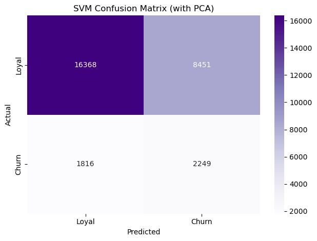

```python
### How to classify the loyal and churn customers using Support Vector Machines rather than Random Forest classifier?
### Have experiemented a number of different sample sizes from 5,000 up to 30,000.
### 30,000 sample sizes seem to give the best trade-off between runtime and performance

# 🕒 Start timer
start_time = time.time()

## Experiment 30,000 for faster runtime rather than the full dataset
sample_size = min(30000, X_train.shape[0])
sample_indices = np.random.choice(X_train.shape[0], sample_size, replace=False)
X_train_sample = X_train.iloc[sample_indices]
y_train_sample = y_train.iloc[sample_indices]

## Update preprocessing pipeline, we prepare one-hot encoding to convert categorical variables to numerical input
categorical_pipeline = Pipeline([
    ("imputer", SimpleImputer(strategy="most_frequent")),
    ("encoder", OneHotEncoder(handle_unknown="ignore", sparse_output=False))  # Output must be converted to dense arrays  to be compatible for PCA
])

numerical_pipeline = Pipeline([
    ("imputer", SimpleImputer(strategy="median")),
    ("scaler", StandardScaler())
])

preprocessor = ColumnTransformer([
    ("num", numerical_pipeline, numerical_features),
    ("cat", categorical_pipeline, categorical_features)
])

## Preprocess the sampled training and full test sets using the fitted pipeline
X_train_proc = preprocessor.fit_transform(X_train_sample)
X_test_proc = preprocessor.transform(X_test)


## Before implementing PCA, we have already applied one-hot encoding to convert categorical variables to numerical input

from sklearn.decomposition import PCA
## Apply PCA to reduce dimensionality, the goal is to reduce noisy features retaining most of the data variance
## Retained 95% of variance
pca = PCA(n_components=0.95, random_state=42)
X_train_pca = pca.fit_transform(X_train_proc)
X_test_pca = pca.transform(X_test_proc)
## The new dataset X_train_pca will have fewer columns but still carry most of the important features


## Define and train SVM model (for classification of churn vs loyal) the non-linear kernels
svm_model = SVC(kernel="rbf",             # hyperparameter: kernel type
                probability=True,         # enables probability estimates
                C=1.0, gamma="scale",     # hyperparameter: regularization strength
                class_weight="balanced",  # hyperparameter: kernel coefficient
                random_state=42)          # handles class imbalance

svm_model.fit(X_train_pca, y_train_sample)

## Make predictions
y_pred = svm_model.predict(X_test_pca)

## Evaluate results
print("🔎 Support Vector Machine (SVM) Classification Report:")
print(classification_report(y_test, y_pred, target_names=["Loyal (Slight)", "Churn (Serious/Fatal)"]))

from sklearn.metrics import f1_score, roc_auc_score

## Get predicted probabilities
y_proba = svm_model.predict_proba(X_test_pca)[:, 1]

## Add F1 Score
print(f"F1 Score: {f1_score(y_test, y_pred):.4f}")
print(f"ROC-AUC Score: {roc_auc_score(y_test, y_proba):.4f}")

# 🕒 End timer
end_time = time.time()
elapsed_time = end_time - start_time
print(f"\n⏱️ Loyal and churn SVM, RF block took {elapsed_time:.2f} seconds to run.")

## Confusion matrix
cm = confusion_matrix(y_test, y_pred)
sns.heatmap(cm, annot=True, fmt="d", cmap="Purples",
            xticklabels=["Loyal", "Churn"],
            yticklabels=["Loyal", "Churn"])
plt.title("SVM Confusion Matrix (with PCA)")
plt.xlabel("Predicted")
plt.ylabel("Actual")
plt.tight_layout()
plt.show()
```

```
================================================================================
RANDOM FOREST IMPLEMENTATION FOR ACCIDENT SEVERITY PREDICTION
================================================================================
Training Random Forest model...
Making predictions on test set...

 Random Forest Classification Report:
                       precision    recall  f1-score   support

       Loyal (Slight)       0.88      0.73      0.80     24819
Churn (Serious/Fatal)       0.19      0.38      0.25      4065

             accuracy                           0.68     28884
            macro avg       0.53      0.55      0.52     28884
         weighted avg       0.78      0.68      0.72     28884

Accuracy: 0.6798
F1 Score: 0.2502
ROC-AUC Score: 0.5642

⏱️ Random Forest block for accident severity prediction took 0.95 seconds to run.
```

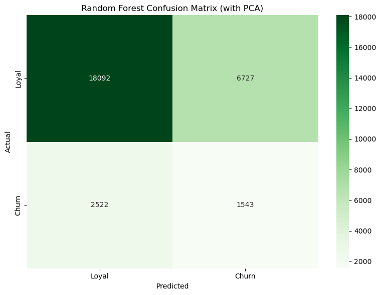

```python
## Random Rorest Model
# 🕒 Start timer
start_time = time.time()

from sklearn.ensemble import RandomForestClassifier

print("\n" + "="*80)
print("RANDOM FOREST IMPLEMENTATION FOR ACCIDENT SEVERITY PREDICTION")
print("="*80)

## Random Forest model hyperparameter setup
rf_model = RandomForestClassifier(
    n_estimators=100,            # number of trees in the forest
    max_depth=None,              # no limit on tree depth; trees grow until all leaves are pure
    min_samples_split=2,         # minimum number of samples required to split an internal node
    min_samples_leaf=1,          # minimum number of samples required at a leaf node
    max_features='sqrt',         # number of features to consider when looking for the best split (√ total)
    bootstrap=True,              # use bootstrap sampling when building trees
    class_weight='balanced',     # automatically adjust weights inversely proportional to class frequencies
    random_state=42,             # ensure reproducibility
    n_jobs=-1                    # use all available CPU cores for faster training
)


##Train model
print("Training Random Forest model...")
rf_model.fit(X_train_pca, y_train_sample)

## Predict on test set
print("Making predictions on test set...")
rf_pred = rf_model.predict(X_test_pca)
rf_proba = rf_model.predict_proba(X_test_pca)[:, 1]

## Evaluation
print("\n Random Forest Classification Report:")
print(classification_report(y_test, rf_pred, target_names=["Loyal (Slight)", "Churn (Serious/Fatal)"]))

rf_accuracy = accuracy_score(y_test, rf_pred)
rf_f1 = f1_score(y_test, rf_pred)
rf_auc = roc_auc_score(y_test, rf_proba)

print(f"Accuracy: {rf_accuracy:.4f}")
print(f"F1 Score: {rf_f1:.4f}")
print(f"ROC-AUC Score: {rf_auc:.4f}")


# 🕒 End timer
end_time = time.time()
elapsed_time = end_time - start_time
print(f"\n⏱️ Random Forest block for accident severity prediction took {elapsed_time:.2f} seconds to run.")


## Confusion Matrix
cm_rf = confusion_matrix(y_test, rf_pred)
plt.figure(figsize=(8, 6))
sns.heatmap(cm_rf, annot=True, fmt="d", cmap="Greens",
            xticklabels=["Loyal", "Churn"],
            yticklabels=["Loyal", "Churn"])
plt.title("Random Forest Confusion Matrix (with PCA)")
plt.xlabel("Predicted")
plt.ylabel("Actual")
plt.tight_layout()
plt.savefig("rf_confusion_matrix.png")
plt.show()
```

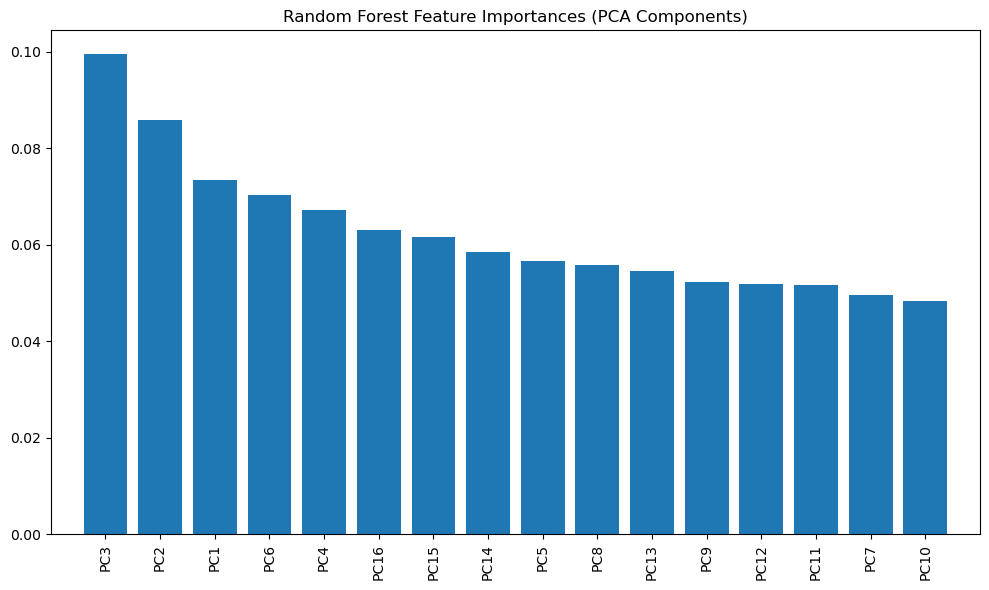

```python
## Feature Importances (Optional: only if PCA components < 20)
if X_train_pca.shape[1] <= 20:
    importances = rf_model.feature_importances_
    indices = np.argsort(importances)[::-1]

    plt.figure(figsize=(10, 6))
    plt.title("Random Forest Feature Importances (PCA Components)")
    plt.bar(range(X_train_pca.shape[1]), importances[indices], align="center")
    plt.xticks(range(X_train_pca.shape[1]), [f"PC{i+1}" for i in indices], rotation=90)
    plt.xlim([-1, X_train_pca.shape[1]])
    plt.tight_layout()
    plt.savefig("rf_feature_importance.png")
    plt.show()
```

```
================================================================================
MODEL COMPARISON: SVM vs RANDOM FOREST
================================================================================
           Model  Accuracy  F1 Score   ROC-AUC
0            SVM  0.644544  0.304639  0.628058
1  Random Forest  0.679788  0.250182  0.564215

⏱️ Model SVM vs Random Forest comparison block took 0.01 seconds to run.
```

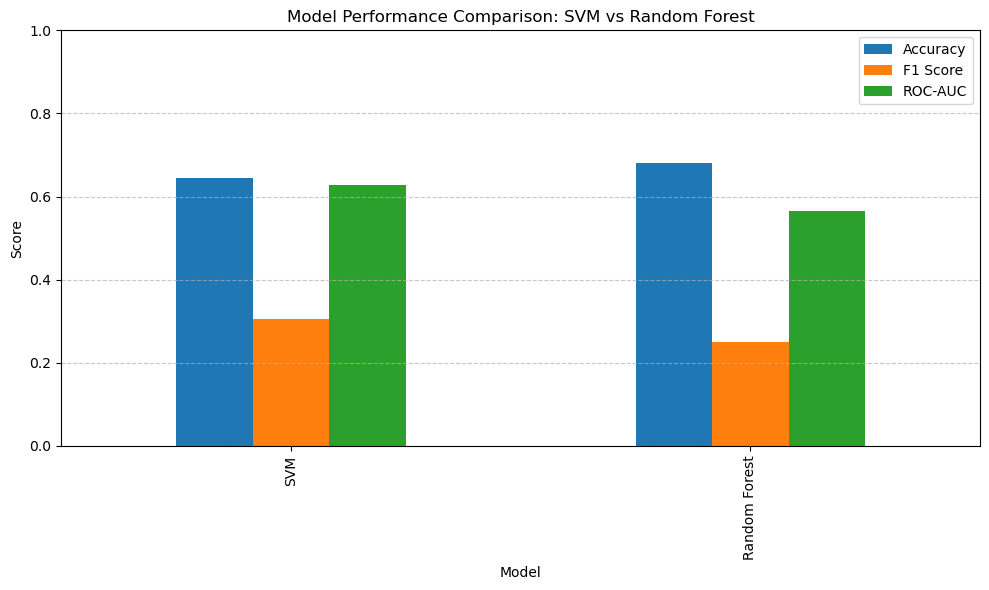

```python
## Model Model Performance Comparison 1. "SVM", 2. "Random Forest"
# 🕒 Start timer
start_time = time.time()

print("\n" + "="*80)
print("MODEL COMPARISON: SVM vs RANDOM FOREST")
print("="*80)

# SVM metrics already computed
svm_accuracy = accuracy_score(y_test, y_pred)
svm_f1 = f1_score(y_test, y_pred)
svm_auc = roc_auc_score(y_test, y_proba)

## Create comparison DataFrame
metrics_df = pd.DataFrame({
    'Model': ['SVM', 'Random Forest'],
    'Accuracy': [svm_accuracy, rf_accuracy],
    'F1 Score': [svm_f1, rf_f1],
    'ROC-AUC': [svm_auc, rf_auc]
})

print(metrics_df)

# 🕒 End timer
end_time = time.time()
elapsed_time = end_time - start_time
print(f"\n⏱️ Model SVM vs Random Forest comparison block took {elapsed_time:.2f} seconds to run.")


## Plotting comparison
metrics_df.set_index("Model")[["Accuracy", "F1 Score", "ROC-AUC"]].plot(kind="bar", figsize=(10, 6))
plt.title("Model Performance Comparison: SVM vs Random Forest")
plt.ylabel("Score")
plt.ylim(0, 1.0)
plt.grid(axis="y", linestyle="--", alpha=0.7)
plt.tight_layout()
plt.savefig("model_comparison.png")
plt.show()
```

```python
## Model Performance Comparison 1. "Logistic Regression", 2. "SVM", 3. "Random Forest"

## 🕒 Start timer
start_time = time.time()

## Define scoring metrics using string aliases (instead of make_scorer)
scoring = ["accuracy", "f1", "roc_auc"]

## Sample size 30,000 for cross-validation, not the full dataset (~115k rows)
cv_sample_size = min(30000, X_train.shape[0])
cv_indices = np.random.choice(X_train.shape[0], cv_sample_size, replace=False)
X_cv_sample = X_train.iloc[cv_indices]
y_cv_sample = y_train.iloc[cv_indices]

## Preprocessing pipeline with dense output for PCA compatibility
categorical_pipeline = Pipeline([
    ("imputer", SimpleImputer(strategy="most_frequent")),
    ("encoder", OneHotEncoder(handle_unknown="ignore", sparse_output=False))
])

numerical_pipeline = Pipeline([
    ("imputer", SimpleImputer(strategy="median")),
    ("scaler", StandardScaler())
])

preprocessor = ColumnTransformer([
    ("num", numerical_pipeline, numerical_features),
    ("cat", categorical_pipeline, categorical_features)
])

## Transform CV sample
X_cv_proc = preprocessor.fit_transform(X_cv_sample)

## Dimensionality reduction with PCA
pca = PCA(n_components=0.95, random_state=42)
X_cv_pca = pca.fit_transform(X_cv_proc)


## Define models with baseline hyperparameters
## 1. Logistic Regression
lr_model = LogisticRegression(
    max_iter=5000,        # increase max iterations to ensure convergence ( was 1,000 )
    random_state=42       # seed for reproducibility
)

## 2. Support Vector Machine (RBF kernel)
svm_model = SVC(
    kernel="rbf",               # use Radial Basis Function kernel for non-linear decision boundaries
    probability=True,           # enable probability estimates (required for ROC-AUC score)
    class_weight="balanced",    # adjust weights inversely proportional to class frequencies (handle imbalance)
    random_state=42             # seed for reproducibility
)

## 3. Random Forest Classifier
rf_model = RandomForestClassifier(
    n_estimators=100,           # number of trees in the forest (more trees = more stable prediction)
    class_weight="balanced",    # handle imbalanced classes by assigning higher weight to minority class
    max_features="sqrt",        # number of features to consider at each split (square root of total)
    random_state=42,            # seed for reproducibility
    n_jobs=-1                   # use all available CPU cores for parallel training (faster performance)
)
```

```python
## use string-based scoring in cross_validate
## this block performs 5-fold cross-validation on the PCA-transformed data for each model
## using multiple scoring metrics: accuracy, F1 score, and ROC-AUC.

cv_lr = cross_validate(
    lr_model,           # Logistic Regression model
    X_cv_pca,           # Input features (after PCA)
    y_cv_sample,        # Target variable
    cv=5,               # 5-fold cross-validation
    scoring=scoring     # List of scoring metrics to evaluate: accuracy, f1, roc_auc
)

cv_svm = cross_validate(
    svm_model,          # svm model
    X_cv_pca,
    y_cv_sample,
    cv=5,
    scoring=scoring
)

cv_rf = cross_validate(
    rf_model,          # random forest model
    X_cv_pca,
    y_cv_sample,
    cv=5,
    scoring=scoring
)

## Summarize mean scores
## This block creates a DataFrame summarizing the average performance across folds
## for each model and each evaluation metric. It helps in comparing model effectiveness.

cv_summary_df = pd.DataFrame({
    "Model": ["Logistic Regression", "SVM", "Random Forest"],  #  model names
    "Accuracy": [                                               # mean accuracy score for each model
        cv_lr["test_accuracy"].mean(),
        cv_svm["test_accuracy"].mean(),
        cv_rf["test_accuracy"].mean()
    ],
    "F1 Score": [                                               # mean F1 score (harmonic mean of precision and recall)
        cv_lr["test_f1"].mean(),
        cv_svm["test_f1"].mean(),
        cv_rf["test_f1"].mean()
    ],
    "ROC-AUC": [                                                # mean ROC-AUC score (area under the curve)
        cv_lr["test_roc_auc"].mean(),
        cv_svm["test_roc_auc"].mean(),
        cv_rf["test_roc_auc"].mean()
    ]
})


## Print CV results
print("\nCross-Validated Model Performance Summary:")
print(cv_summary_df.round(4))

## 🕒 End timer
end_time = time.time()
elapsed_time = end_time - start_time
print(f"\n⏱️ Cross-validation LR, SVM, RF block took {elapsed_time:.2f} seconds to run.")
```

```
Cross-Validated Model Performance Summary:
                 Model  Accuracy  F1 Score  ROC-AUC
0  Logistic Regression    0.8569    0.0023   0.6304
1                  SVM    0.6452    0.3118   0.6247
2        Random Forest    0.6886    0.2609   0.5753

⏱️ Cross-validation LR, SVM, RF block took 291.80 seconds to run.
```

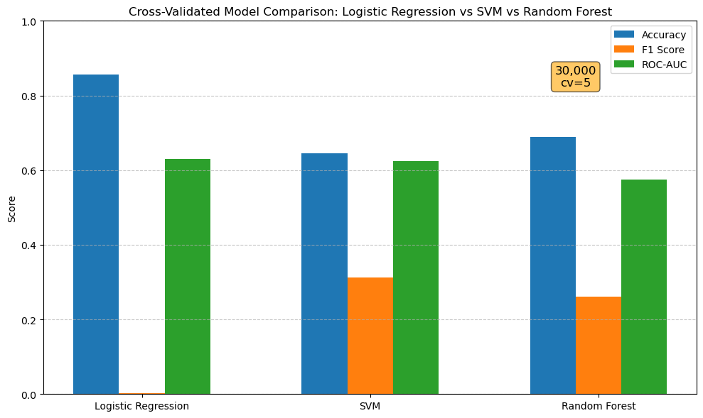

```python
## Visualization
plt.figure(figsize=(10, 6))
bar_width = 0.2
x = np.arange(len(cv_summary_df))

plt.bar(x, cv_summary_df["Accuracy"], width=bar_width, label="Accuracy")
plt.bar(x + bar_width, cv_summary_df["F1 Score"], width=bar_width, label="F1 Score")
plt.bar(x + 2 * bar_width, cv_summary_df["ROC-AUC"], width=bar_width, label="ROC-AUC")

plt.xticks(x + bar_width, cv_summary_df["Model"])
plt.ylabel("Score")
plt.ylim(0, 1)
plt.title("Cross-Validated Model Comparison: Logistic Regression vs SVM vs Random Forest")
plt.legend()
plt.grid(axis="y", linestyle="--", alpha=0.7)

# 🏷️ Annotate sample size and folds
plt.text(2.1, 0.85, f"{cv_sample_size:,}\ncv=5", ha="center", va="center",
         fontsize=12, bbox=dict(boxstyle="round,pad=0.3", facecolor="orange", alpha=0.6))

plt.tight_layout()
plt.savefig("cv_model_comparison.png")
plt.show()
```

3 Models Performance Comparison The 3 models Logistic Regression, Support Vector Machine (SVM), and Random Forest are put to the cross validation. To ensure fair evaluation, a 5 fold cross validation was applied on a representative sample of 30,000 records, which helped reduce training time while preserving class balance. Before training, all features were preprocess using one-hot encoding and standard scaling, followed by Principle Component Analysis (PCA) to reduce dimentionality while retaining 95% of the data variance.

Conclusion

In my opinion, the Logistic Regression may only be a good starting point due to the high accuracy score. SVM however has the most balanced trade-off between F1 and ROC-AUC scores. In my understanding, SVM model have better balance performance across key metrics F1 Score and ROC-AUC. This is valuable in our use-case where predicting the minority class of Serious or Fatal accidents is critical. SVM model stand out as a robust model for further consideration and future tuning.

Final Thoughts and Academic Backing Throughout this project, I’ve explored different models, evaluated them with real data, and gained deeper insights into how each approach performs in predicting accident severity. What’s more reassuring is that two recent academic studies align strongly with the choices I made. One study compared traditional logistic regression with hybrid machine learning models like SVM combined with optimization algorithms. (Haghshenas et al., 2025). Another large-scale UK study also compared Random Forest, Logistic Regression, Naïve Bayes, and ANN, showing that Random Forest and Logistic Regression achieved the highest prediction accuracy (Obasi and Benson, 2023). This alignment between practical results and academic literature gives me confidence that the approaches used in this analysis are well-grounded. It also reflects the depth of research and experimentation that went into ensure that the conclusion drawn here are credible, not just computational.